# Assignment 2

# Hypothesis testing

We will test the following hypotheses:

Hypotheses

| H0 | HA | Variable | Test |
| --- | --- | --- | --- |
| Environmental concern does not vary by region of living | Environmental concern varies by region of living | TH_REG | ANOVA |
| Environmental concern does not vary by place of living | Environmental concern varies by place of living | place20 | ANOVA |
| Environmental concern does not vary by household income | Environmental concern varies by household income | INC_cat | ANOVA |
| Environmental concern does not vary by years of education | Environmental concern varies by years of education | educyrs_cat | ANOVA |
| Environmental concern does not vary by age | Environmental concern varies by age | AGE | ANOVA |
| Environmental concern does not vary by sex | Environmental concern varies by sex | SEX | T-Test |

We will use the following code to test the hypotheses:

```r
#Calculate the population mean for comparison
population_mean <- mean(Assignment_2_vars$env_concern, na.rm = TRUE)

#ANOVA for TH_REG
anova_reg <- aov(env_concern ~ TH_REG, data = Assignment_2_vars)
reg_boxpolot <- ggplot(Assignment_2_vars, aes(x = TH_REG, y = env_concern)) +
  geom_boxplot() +
  ggtitle("Boxplot of Environmental Concern by Region of Living") +
  labs(x = "Region of Living", y = "Environmental Concern") +
 geom_hline(yintercept = population_mean, linetype = "dashed", color = "red") +
  theme_minimal() +
  scale_fill_brewer(palette = "Set3")
summary(anova_reg)
```

```
##               Df Sum Sq Mean Sq F value Pr(>F)
## TH_REG         4   60.8  15.208   47.04 <2e-16 ***
## Residuals   1454  470.1   0.323
## ---
## Signif. codes:  0 '***' 0.001 '**' 0.01 '*' 0.05 '.' 0.1 ' ' 1
## 39 observations deleted due to missingness
```

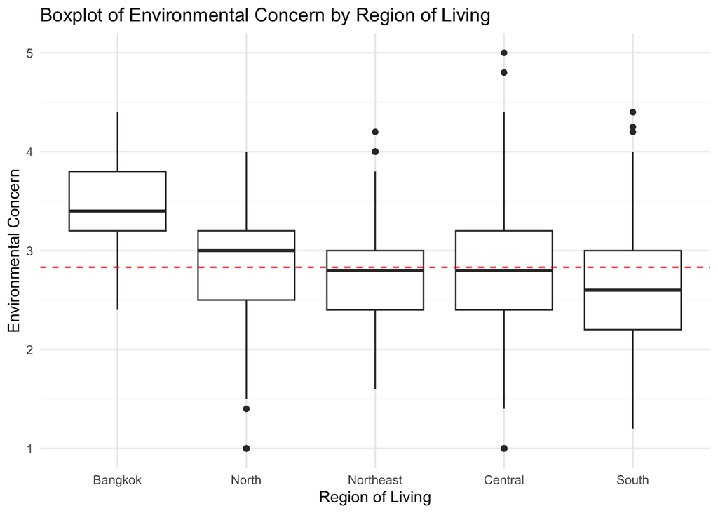

```r
print(reg_boxpolot)
```

```r
#ANOVA for place20
anova_place <- aov(env_concern ~ place20, data = Assignment_2_vars)
place_boxplot <- ggplot(Assignment_2_vars, aes(x = place20, y = env_concern)) +
  geom_boxplot() +
  ggtitle("Boxplot of Environmental Concern by Place of Living") +
  labs(x = "Place of Living", y = "Environmental Concern") +
  theme(axis.text.x = element_text(angle = 45, hjust = 1)) +
  geom_hline(yintercept = population_mean, col="red", linetype="dashed") +
  theme_minimal()
summary(anova_place)
```

```
##               Df Sum Sq Mean Sq F value Pr(>F)
## place20        4   54.2  13.551   41.33 <2e-16 ***
## Residuals   1454  476.7   0.328
## ---
## Signif. codes:  0 '***' 0.001 '**' 0.01 '*' 0.05 '.' 0.1 ' ' 1
## 39 observations deleted due to missingness
```

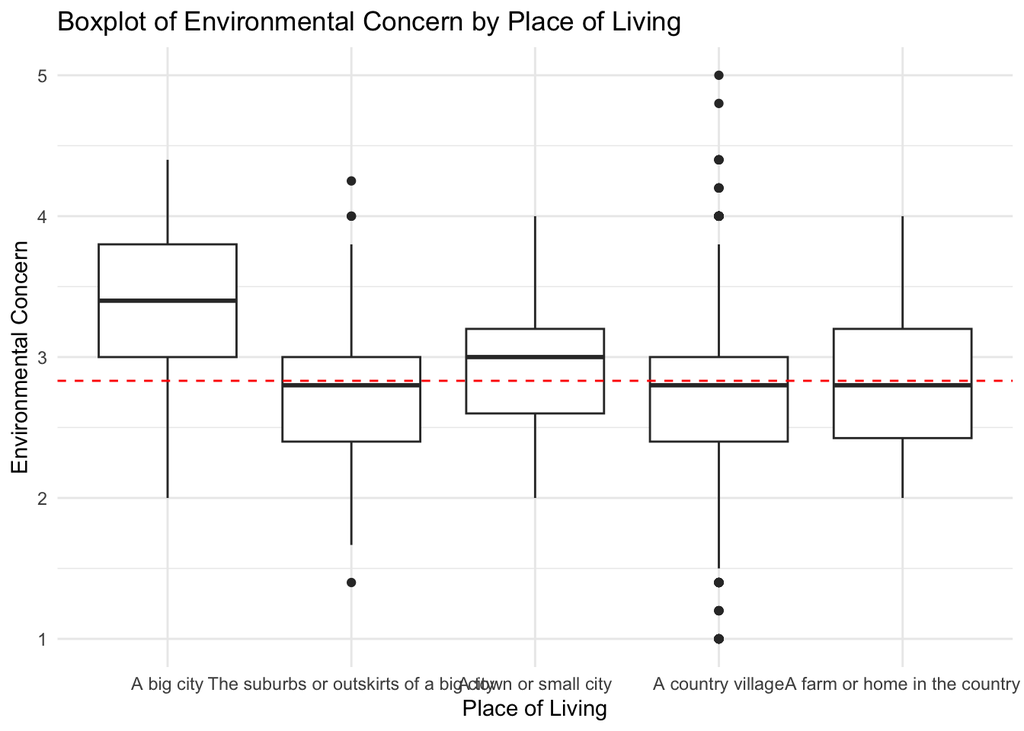

```r
print(place_boxplot)
```

```r
#Anova for TH_INC
#Make 3 income categories, low <15000, medium 15000-30000, high >30000
anova_inc <- aov(env_concern ~ INC_cat, data = Assignment_2_vars)
inc_boxplot <- ggplot(Assignment_2_vars, aes(x = INC_cat, y = env_concern)) +
  geom_boxplot() +
  ggtitle("Boxplot of Environmental Concern by Household Income") +
  labs(x = "Household Income", y = "Environmental Concern") +
  theme_minimal() +
  geom_hline(yintercept = population_mean, col="red", linetype="dashed")
summary(anova_inc)
```

```
##               Df Sum Sq Mean Sq F value Pr(>F)
## INC_cat        2   30.2  15.082   46.14 <2e-16 ***
## Residuals   1043  341.0   0.327
## ---
## Signif. codes:  0 '***' 0.001 '**' 0.01 '*' 0.05 '.' 0.1 ' ' 1
## 452 observations deleted due to missingness
```

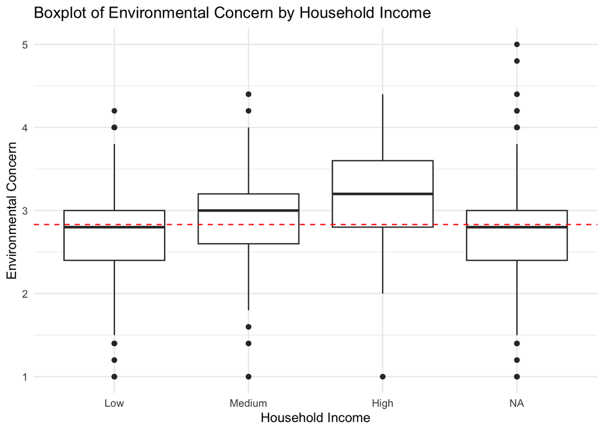

```r
plot(inc_boxplot)
```

```r
#Anova for EDUCYRS
anova_edu <- aov(env_concern ~ educyrs_cat, data = Assignment_2_vars)
edu_boxplot <- ggplot(Assignment_2_vars, aes(x = educyrs_cat, y = env_concern)) +
  geom_boxplot() +
  ggtitle("Boxplot of Environmental Concern by Years of Education") +
  labs(x = "Years of Education", y = "Environmental Concern") +
  theme_minimal() +
  geom_hline(yintercept = population_mean, col="red", linetype="dashed")
summary(anova_edu)
```

```
##               Df Sum Sq Mean Sq F value Pr(>F)
## educyrs_cat    6    5.9  0.9913    2.74 0.0119 *
## Residuals   1428  516.6  0.3618
## ---
## Signif. codes:  0 '***' 0.001 '**' 0.01 '*' 0.05 '.' 0.1 ' ' 1
## 63 observations deleted due to missingness
```

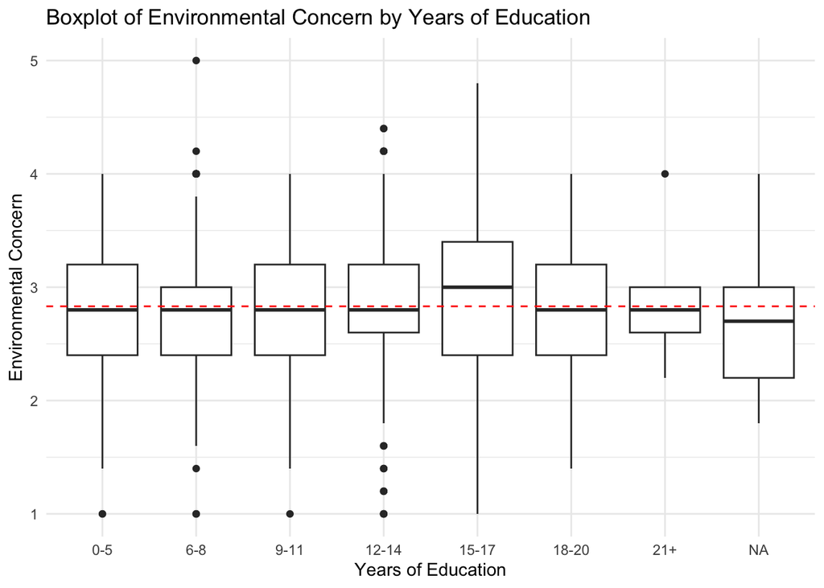

```r
plot(edu_boxplot)
```

```r
#anova for AGE
anova_age <- aov(env_concern ~ age_cat, data = Assignment_2_vars)
age_boxplot <- ggplot(Assignment_2_vars, aes(x = age_cat, y = env_concern)) +
  geom_boxplot() +
  ggtitle("Boxplot of Environmental Concern by Age") +
  labs(x = "Age", y = "Environmental Concern") +
  theme_minimal() +
  geom_hline(yintercept = population_mean, col="red", linetype="dashed")
summary(anova_age)
```

```
##               Df Sum Sq Mean Sq F value Pr(>F)
## age_cat        6    1.6  0.2666   0.731  0.624
## Residuals   1452  529.3  0.3645
## 39 observations deleted due to missingness
```

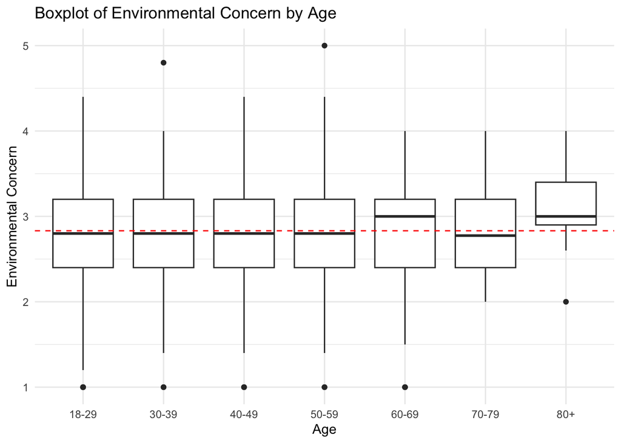

```r
print(age_boxplot)
```

```r
#T-test for sex
ttest_sex <- t.test(env_concern ~ SEX, data = Assignment_2_vars)
sex_boxplot <- ggplot(Assignment_2_vars, aes(x=SEX, y=env_concern)) +
  geom_boxplot() +
  ggtitle("Boxplot of Environmental Concern by Sex") +
  labs(x = "Sex", y = "Environmental Concern") +
  theme_minimal() +
  geom_hline(yintercept = population_mean, col="red", linetype="dashed")
print(ttest_sex)
```

```
##
##  Welch Two Sample t-test
##
## data:  env_concern by SEX
## t = 0.24758, df = 1376.4, p-value = 0.8045
## alternative hypothesis: true difference in means between group Male and group Female is not equal to 0
## 95 percent confidence interval:
##  -0.05458209  0.07034930
## sample estimates:
##   mean in group Male mean in group Female
##             2.836029             2.828145
```

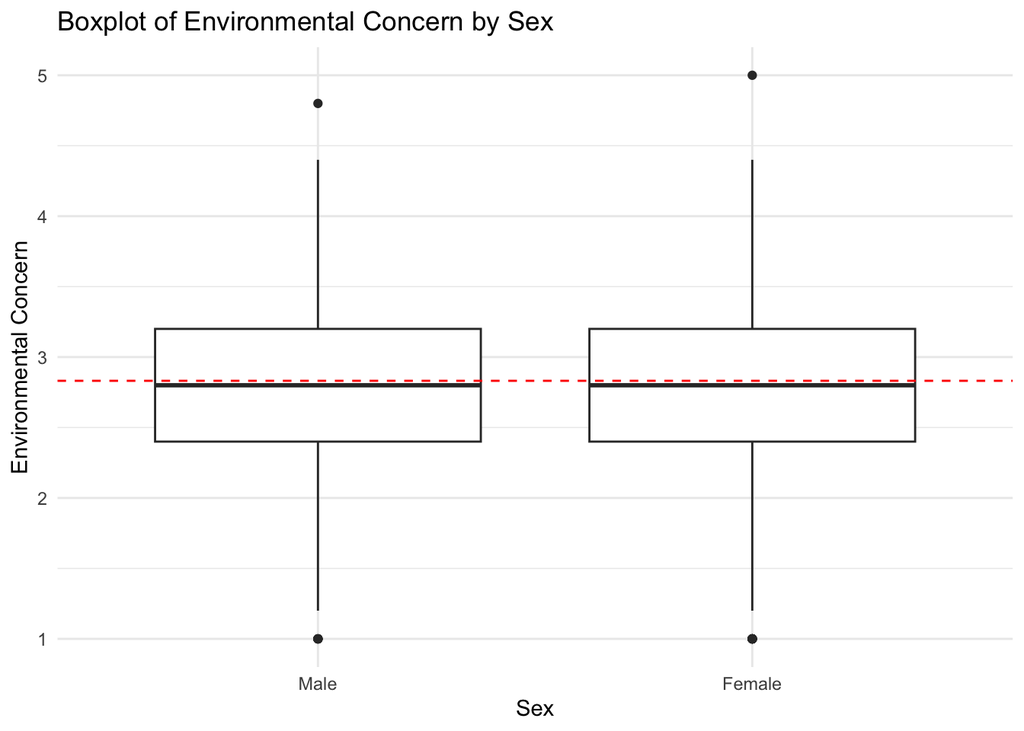

```r
print(sex_boxplot)
```

# Results

The results of the ANOVA tests show that environmental concern varies highly significantly by region of living (F(4, 1454) = 47.04, p = <2e-16), place of living (F(4, 1454) = 41.33, p = <2e-16), and household income (F(2, 1043) = 46.14, p = <2e-16). However, environmental concern does not vary as significantly by years of education (F(6, 1428) = 2.74, p = 0.0119). Results for age and gender tests did not reveal any significant differences in environmental concern. This gives us some evidence to support the hypotheses that environmental concern varies by region of living, place of living, and household income, which is the starting point for some more advanced modeling techniques!